# 近江貝塚研第324回例会「陽明文庫所蔵史料と松尾大社所蔵史料の料紙における構成物の変化」関連データ

# 松尾大社社蔵史料の料紙構成物における時期的変化

## 細胞組織・柔細胞

```r
# Fig3(1)作成のためのCSVファイルの読み取り
tissue <- read_csv("matsunoo_tissue-fibre.csv")

head(tissue)　 # データフレームの上6行を表示
```

```
# A tibble: 6 x 4
  史料名              西暦 細胞組織  繊維
  <chr>              <dbl>    <dbl> <dbl>
1 池田庄立券文（案）  1171      0    0
2 左辨官下文          1181     55.2  0.67
3 源頼朝下知状        1196     87.7  0
4 沙彌證阿譲状        1197     39.3  0.83
5 左辨官下文（残欠）  1204     34.5  1
6 兩六波羅下知状      1231     34.5  1
```

```r
names(tissue)  # tissue-fibreに含まれるすべての変数名
```

```
[1] "史料名"   "西暦"     "細胞組織" "繊維"
```

```r
dim(tissue)　  # tissue-fibreに含まれる観測数と変数の数を表示させる
```

```
[1] 63  4
```

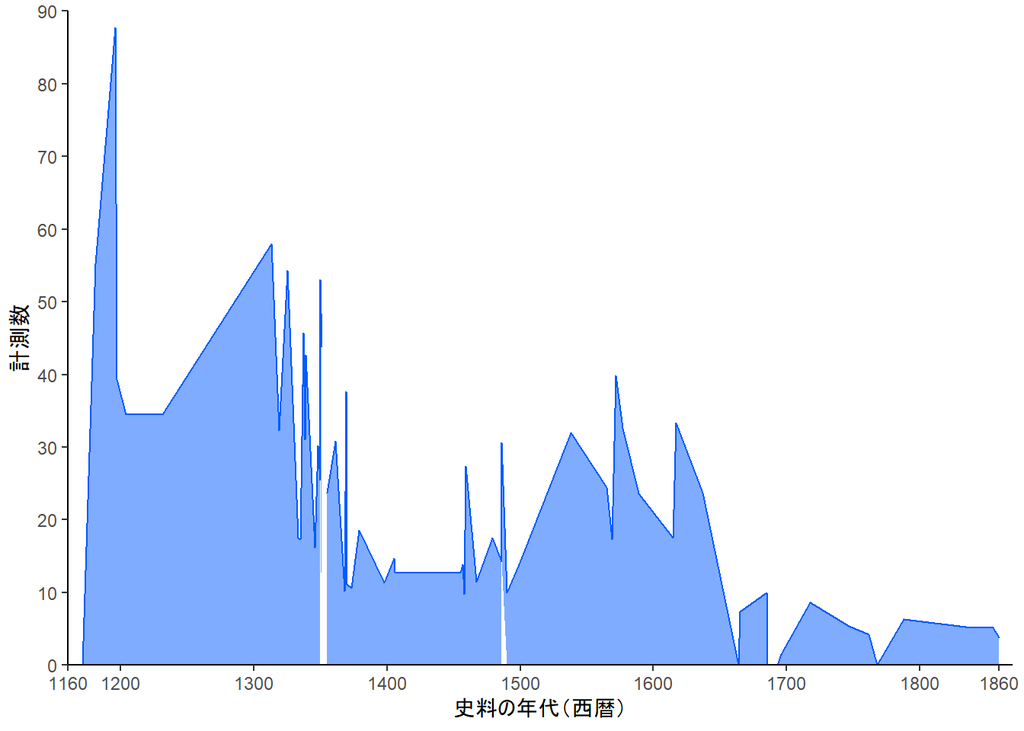

```r
ggplot(tissue, aes(x = 西暦, y = 細胞組織)) +
  geom_area(colour = "#005aff", fill ="#005aff", alpha=0.5) + # 網掛け領域付きの折れ線グラフの作成
  scale_x_continuous(breaks = c(1160,1200,1300,1400,1500,1600,1700,1800,1860),
                     limits = c(1160,1870), expand = c(0,0)) + # X軸の目盛りを指定
  scale_y_continuous(breaks = c(0,10,20,30,40,50,60,70,80,90), limits = c(0,90), expand = c(0,0))+ # Y軸の目盛りを指定
  labs(x = "史料の年代（西暦）", y = "計測数") + # ラベルの指定
  theme_classic()
```

```r
ggsave(file = "Fig15.png", width = 6, height = 4, dpi = 300) # ファイルの保存
```

調査史料では1300年代と1600年代後半に画期がある。

## 繊維

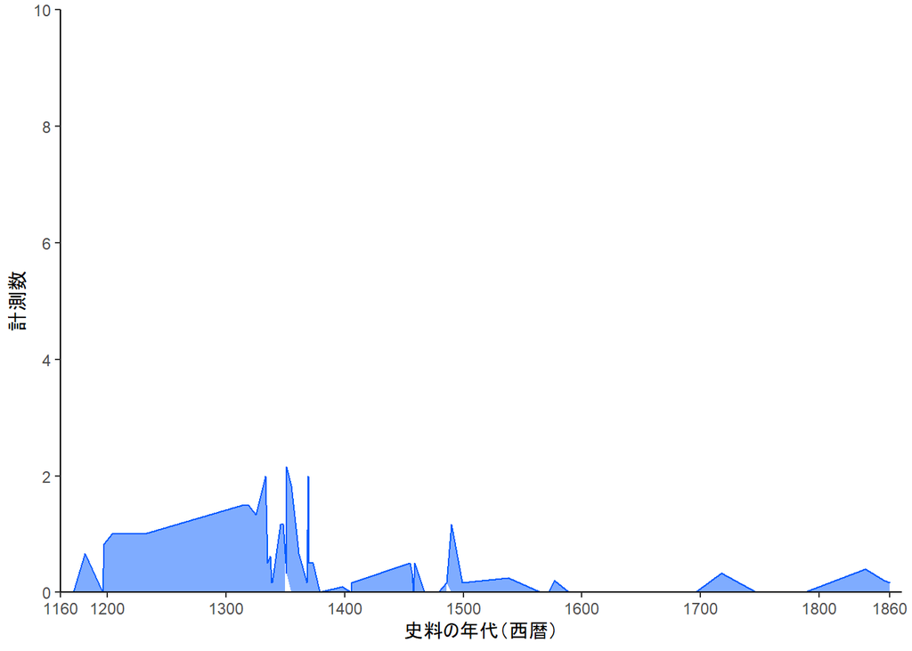

```r
ggplot(tissue, aes(x = 西暦, y = 繊維)) +
  geom_area(colour = "#005aff", fill ="#005aff", alpha=0.5) + # 網掛け領域付きの折れ線グラフの作成
  scale_x_continuous(breaks = c(1160,1200,1300,1400,1500,1600,1700,1800,1860),
                     limits = c(1160,1870), expand = c(0,0)) + # X軸の目盛りを指定
  scale_y_continuous(breaks = c(0,2,4,6,8,10), limits = c(0,10), expand = c(0,0))+ # Y軸の目盛りを指定
  labs(x = "史料の年代（西暦）", y = "計測数") + # ラベルの指定
  theme_classic()
```

```r
ggsave(file = "Fig16.png", width = 6, height = 4, dpi = 300) # ファイルの保存
```

調査史料では1500年代以降は減少傾向。

# 現生デンプン粒標本と料紙のデンプン粒の比較

## 松尾大社社蔵史料の料紙に含有されたデンプン粒

```r
# Fig1作成のためのCSVファイルの読み取り
starch <- read_csv("matsuono_ryoshi-starch.csv")

head(starch)　 # データフレームの上6行を表示
```

```
# A tibble: 6 x 2
  デンプン粒の種類 粒径範囲
  <chr>               <dbl>
1 現生アワ            10
2 現生アワ            11.5
3 現生アワ             7.69
4 現生アワ             8.46
5 現生アワ            11.5
6 現生アワ             7.69
```

```r
names(starch)  # starchに含まれるすべての変数名
```

```
[1] "デンプン粒の種類" "粒径範囲"
```

```r
dim(starch)　  # starchに含まれる観測数と変数の数を表示させる
```

```
[1] 439   2
```

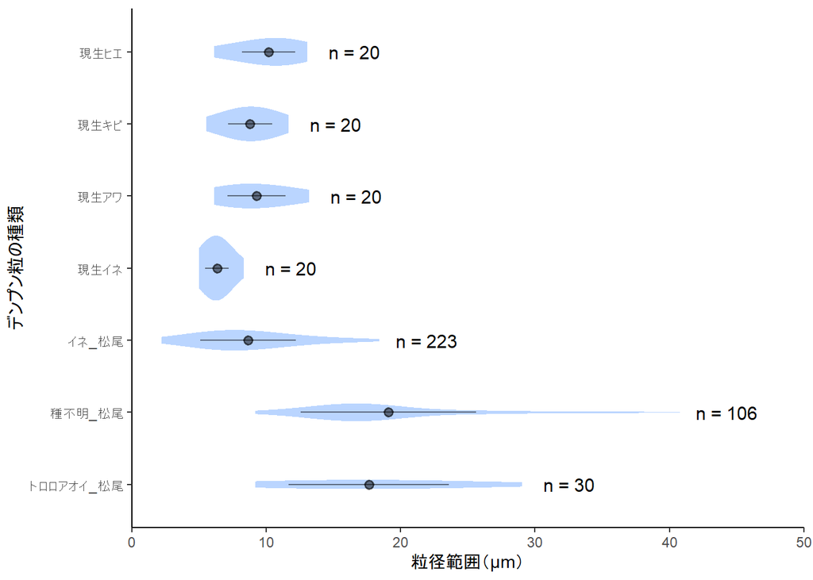

```r
n_fun <- function(x){
return(data.frame(y = max(x)+3.5, label = paste0("n = ",length(x))))
}

ggplot(starch, aes(x = デンプン粒の種類, y = 粒径範囲)) +
  geom_violin(trim=T,fill="#2F80FF",linetype="blank",alpha=I(1/3),adjust=2.5)+ # バイオリンプロット作成
  stat_summary(geom="pointrange",fun = mean, fun.min = function(x) mean(x)-sd(x),
               fun.max = function(x) mean(x)+sd(x), size=.5,alpha=.5)+ # 平均値±標準偏差をプロット
  stat_summary(fun.data = n_fun, geom = "text",colour="black",size=4)+ # 各グループのデータ数を最大値の位置に追加
  scale_y_continuous(breaks = c(0,10,20,30,40,50), limits = c(0,50), expand = c(0,0))+ # 数値軸の目盛りを指定
  scale_x_discrete(limit=c("トロロアオイ_松尾","種不明_松尾","イネ_松尾","現生イネ","現生アワ","現生キビ","現生ヒエ")) +
  # 文字軸の順番を指定
  coord_flip() +　# 90度横向きにする
  labs(x = "デンプン粒の種類", y = "粒径範囲（μm）") + # ラベルの指定
  theme_classic()
```

```r
ggsave(file = "Fig17.png", dpi = 300) # ファイルの保存
```

料紙におけるデンプン粒の粒径は分散が大きい。

## 陽明文庫所蔵史料の料紙に含有されたデンプン粒

```r
# Fig2作成のためのCSVファイルの読み取り
starch <- read_csv("yomei-starch.csv")

head(starch)　 # データフレームの上6行を表示
```

```
# A tibble: 6 x 2
  デンプン粒の種類 粒径範囲
  <chr>               <dbl>
1 現生アワ            10
2 現生アワ            11.5
3 現生アワ             7.69
4 現生アワ             8.46
5 現生アワ            11.5
6 現生アワ             7.69
```

```r
names(starch)  # starchに含まれるすべての変数名
```

```
[1] "デンプン粒の種類" "粒径範囲"
```

```r
dim(starch)　  # starchに含まれる観測数と変数の数を表示させる
```

```
[1] 533   2
```

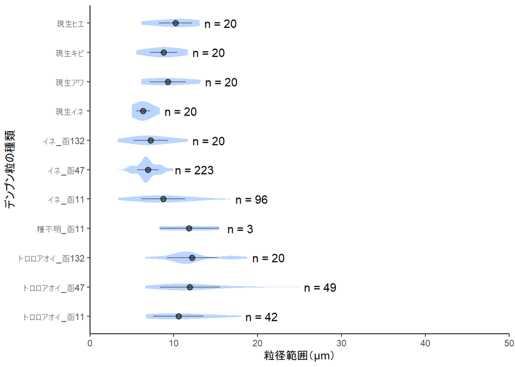

```r
n_fun <- function(x){
return(data.frame(y = max(x)+2.5, label = paste0("n = ",length(x))))
}

ggplot(starch, aes(x = デンプン粒の種類, y = 粒径範囲)) +
  geom_violin(trim=T,fill="#2F80FF",linetype="blank",alpha=I(1/3),adjust=2.5)+ # バイオリンプロット作成
  stat_summary(geom="pointrange",fun = mean, fun.min = function(x) mean(x)-sd(x),
               fun.max = function(x) mean(x)+sd(x), size=.5,alpha=.5)+ # 平均値±標準偏差をプロット
  stat_summary(fun.data = n_fun, geom = "text",colour="black",size=4)+ # 各グループのデータ数を最大値の位置に追加
  scale_y_continuous(breaks = c(0,10,20,30,40,50), limits = c(0,50), expand = c(0,0))+ # 数値軸の目盛りを指定
  scale_x_discrete(limit=c("トロロアオイ_函11","トロロアオイ_函47","トロロアオイ_函132","種不明_函11","イネ_函11","イネ_函47","イネ_函132","現生イネ","現生アワ","現生キビ","現生ヒエ")) + # 文字軸の順番を指定
  coord_flip() +　# 90度横向きにする
  labs(x = "デンプン粒の種類", y = "粒径範囲（μm）") + # ラベルの指定
  theme_classic()
```

```r
ggsave(file = "Fig18.png", dpi = 300) # ファイルの保存
```

料紙におけるデンプン粒の粒径は分散が大きい。

# 引用文献

藤本滋生. 1994. 澱粉と植物―各種植物澱粉の比較―. 葦書房, 東京.  
渋谷綾子. 2010. 日本列島における現生デンプン粒標本と日本考古学研究への応用―残存デンプン粒の形態分類をめざして. 植生史研究18(1): 13-27.